# Web Traffic Time Series Forecasting - Spectral_Analysis_TBATS

Prafulla Ranjan Dash

27th Nov 2020

### Overview

#### Description

We decided to work on one of the most burning time series problem of today’s day and era, “predicting web traffic”. We believe that this forecasting can help website servers a great deal in effectively handling outages. The technique we implemented can be extended to diverse applications in financial markets, weather forecasts, audio and video processing. Not just that, understanding your website’s traffic trajectory can open up business opportunities too.

#### Dataset

The dataset consists of 145k time series representing the number of daily page views of different Wikipedia articles, starting from July 1st, 2015 up until September 10th, 2017 (804 data points).

#### For these models, I have focused on the **Legal_high** wikipedia page

## Spectral Analysis

#### Here, we try and apply Spectral Analysis for detecting the seasonal patterns of our data.

```r
# basic imports
library("fpp", lib.loc="C:/Users/HP/Anaconda3/envs/rstudio/lib/R/library")
library("ggplot2", lib.loc="C:/Users/HP/Anaconda3/envs/rstudio/lib/R/library")
library("stats", lib.loc="C:/Users/HP/Anaconda3/envs/rstudio/lib/R/library")
library("zoo", lib.loc="C:/Users/HP/Anaconda3/envs/rstudio/lib/R/library")
library("TSA", lib.loc="C:/Users/HP/Anaconda3/envs/rstudio/lib/R/library")
```

#### Importing the data

```r
setwd("D:/USMS/UChicago/STUDIES/Autumn 2020/MSCA 31006 1 Time Series Analysis and Forecasting/Final Project/Data")
page_Legalhigh_views <- data.matrix(read.csv("train_1.csv", header = TRUE, row.names = 1,sep = ",",nrows = 1,skip =87))
```

#### Preparing data to make it ready for time-series

```r
# removing column names
dimnames(page_Legalhigh_views) <- NULL

# converting to array
page_Legalhigh_views <- array(page_Legalhigh_views)

# downsampling
page_Legalhigh_views <- rollapply(page_Legalhigh_views, 7, mean)

# checking the values
head(page_Legalhigh_views)
```

```
## [1] 15.71429 14.42857 14.00000 15.42857 12.85714 11.71429
```

```r
# no. of ovservations
length(page_Legalhigh_views)
```

```
## [1] 544
```

#### Splitting to train and test

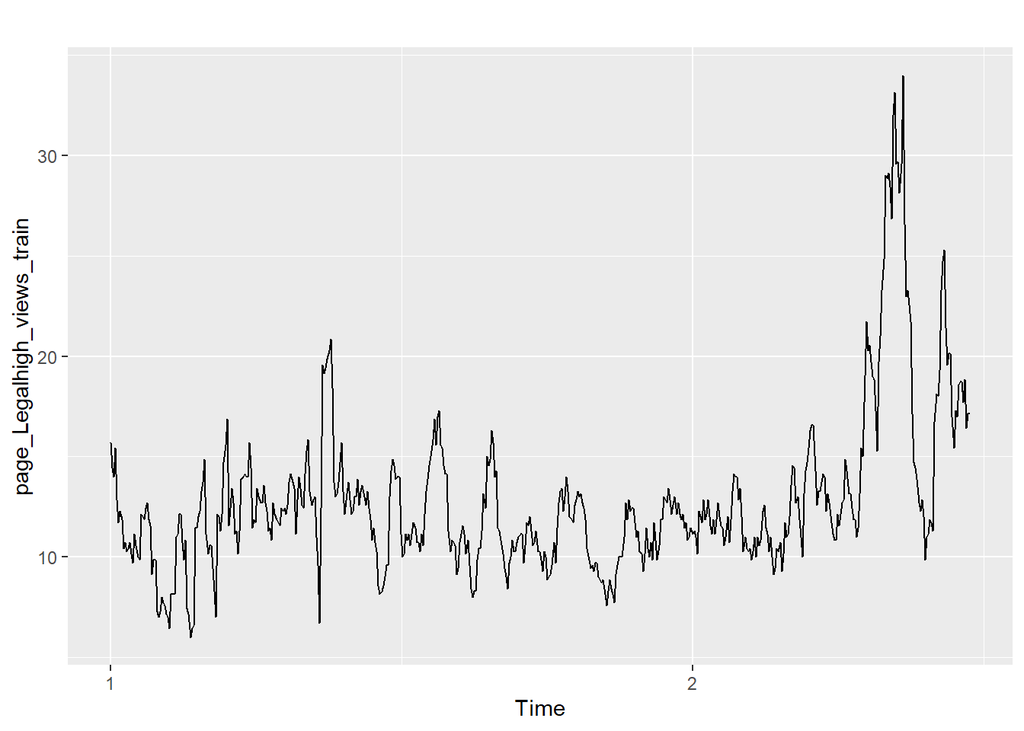

```r
# splitting to train and test
page_Legalhigh_views_train <- page_Legalhigh_views[1:540]
page_Legalhigh_views_test <- page_Legalhigh_views[541:550]

# converting data to ts
page_Legalhigh_views_train <- ts(page_Legalhigh_views_train,frequency = 365.25)
page_Legalhigh_views_test <- ts(page_Legalhigh_views_test,frequency = 365.25)

# plotting the time-series
autoplot(page_Legalhigh_views_train)
```

From the first look of the TS, we can see that there are few values which are kind of deviating from the normal, but let’s NOT consider them as outliers.

We also suspect some kind of **seasonal behaviour** here, with certain periodicities that are repeating themselves. We will try to represent them as a summation of different sine and cosine waves by using **Fourier Transformation**. This signal is also **moving very fast**.

So, before that, we have to ensure that make our data **stationary** by stabilizing it’s variance and applying any **non-seasonal differencing** if required.

Looking at this data, we might have to apply **Box-Cox transformation** to **decouple the mean and variance**.

```r
# finding ideal lambda
BoxCox.lambda(page_Legalhigh_views_train)
```

```
## [1] 1
```

Surprisingly, the ideal lambda value for this is 1, which means it **does not require** box-cox transformation.

Now, let’s check for it’s stationarity by looking at the ACF and PACF

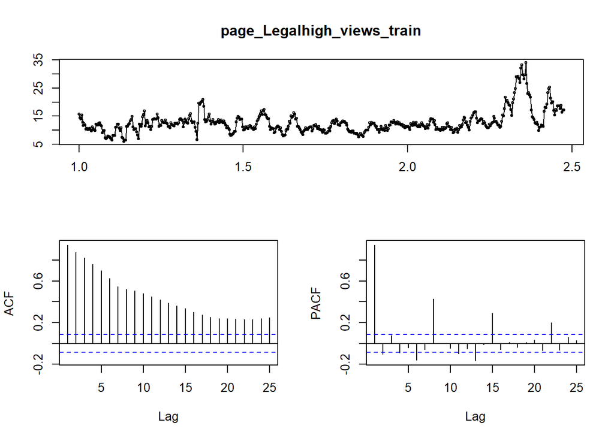

```r
tsdisplay(page_Legalhigh_views_train,lag.max = 25)
```

So, from ACF we see that there is slow exponential decay, which indicates that there is some correlation in our data and the time-series is **NOT stattionary**. We can also apply KPSS test to check stationarity.

```r
kpss.test(page_Legalhigh_views_train)
```

```
##
##  KPSS Test for Level Stationarity
##
## data:  page_Legalhigh_views_train
## KPSS Level = 1.5938, Truncation lag parameter = 6, p-value = 0.01
```

The p-value = 0.01  
=> We reject the NULL hypothesis  
=> The data is **NOT stationary**

Let’s apply one order of **non-seasonal differencing**.

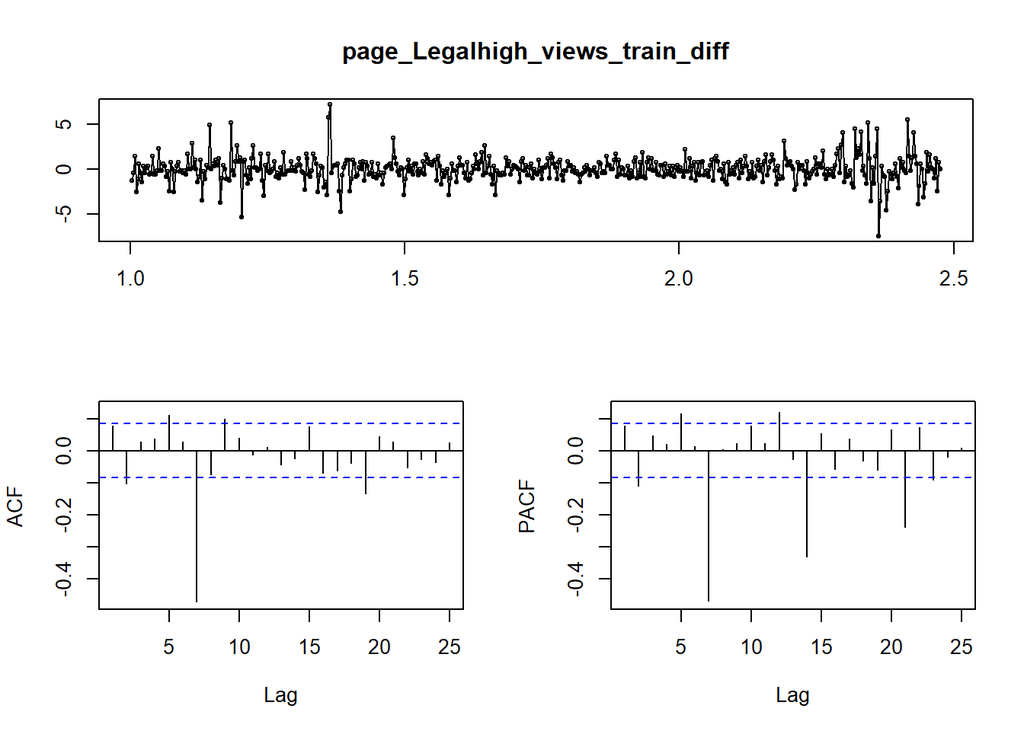

```r
# applying 1st order differencing
page_Legalhigh_views_train_diff <- diff(page_Legalhigh_views_train)

# visualizing data
tsdisplay(page_Legalhigh_views_train_diff,lag.max = 25)
```

```r
kpss.test(page_Legalhigh_views_train_diff)
```

```
##
##  KPSS Test for Level Stationarity
##
## data:  page_Legalhigh_views_train_diff
## KPSS Level = 0.025273, Truncation lag parameter = 6, p-value = 0.1
```

The p-value = 0.1  
=> We fail reject the NULL hypothesis  
=> The data **is stationary**

Now, let’s plot a **periodogram** to check what are the fundamental frequencies that are contributing to our signal.

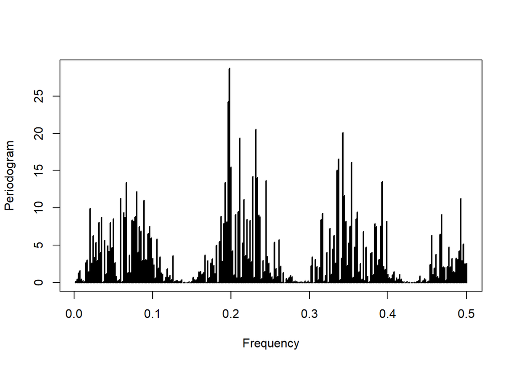

```r
periodogram(page_Legalhigh_views_train_diff)
```

From the above **periodogram**, where we have represented our data in **frequency domain**, we can see that this signal is mostly dictated by **high frequencies** as we have significant spikes for the spectrum in the high frequency ranges. Also, this signal has some cyclical patterns and it is **moving very quickly**.

Now, looking at the spectrum, which represents the same frequencies but in a continuous manner.

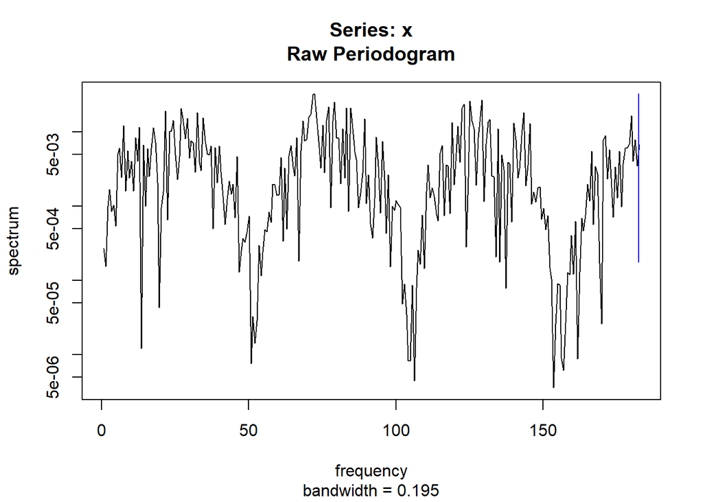

```r
spectrum(page_Legalhigh_views_train_diff)
```

The spectrum of our data also tells a similar story.

Now, let’s zoom in a bit into our periodogram.

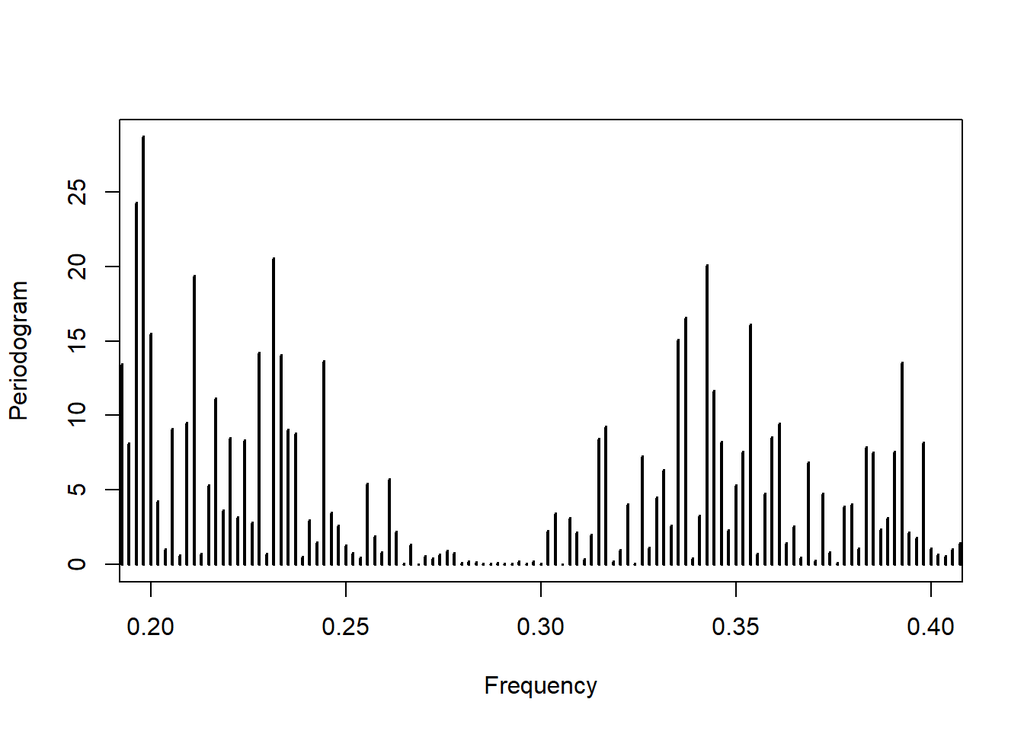

```r
periodogram(page_Legalhigh_views_train_diff,xlim = c(0.2,0.4))
```

From here, we can see that there are certain frequencies that are contributing more to our signal than others.

Let’s what these are.

```r
# storing the periodogram object
page_Legalhigh_periodogram <- periodogram(page_Legalhigh_views_train_diff)
```

[figure not shown]

```r
# storing the top 10 spectrums
high_spectrum <- head(sort(page_Legalhigh_periodogram$spec,decreasing = TRUE),10)
high_spectrum
```

```
##  [1] 28.69579 24.26756 20.56143 20.10402 19.35698 16.57043 16.07897
##  [8] 15.50748 15.08656 14.22669
```

So, we we can see these are the top 10 spectrums that we have in our data. Let’s find their corresponding frequencies.

```r
high_spectrum_indices <- c()

# storing the high spectrum indices
for (i in seq(1:length(high_spectrum))) {
  high_spectrum_indices <- append(high_spectrum_indices,match(high_spectrum[i]
                                                              ,page_Legalhigh_periodogram$spec))
}

fundamental_freq <- c()

# storing the frequencies corresponding to the high spectrums
for (i in seq(1:length(high_spectrum_indices))) {
  fundamental_freq <- append(fundamental_freq,page_Legalhigh_periodogram$freq[high_spectrum_indices[i]])
}

# the fundamental frequencies
fundamental_freq
```

```
##  [1] 0.1981481 0.1962963 0.2314815 0.3425926 0.2111111 0.3370370 0.3537037
##  [8] 0.2000000 0.3351852 0.2277778
```

```r
# finding and storing the time periods
time_periods <- round(1/fundamental_freq,0)
time_periods
```

```
##  [1] 5 5 4 3 5 3 3 5 3 4
```

This is also in accordance with **Nyquist** frequency. Since our sampling frequency is **1 day**, we can detect a cycle that is **atleast 2 days** in length. We **cannot detect** a cycle that is **less** than 2 days.

Now, let’s apply **Regression with ARIMA error** model here, where the regression is nothing but the **Fourier transformation** of the signal so that we can capture this signal deterministically. And then ARIMA can come in and capture the rest which was not captured by Fourier transformation. We will take the maximum number of fourier terms as 3.

```r
m1 <- auto.arima(page_Legalhigh_views_train, xreg = fourier(page_Legalhigh_views_train,K=3),seasonal = FALSE,stationary =FALSE)
summary(m1)
```

```
## Series: page_Legalhigh_views_train
## Regression with ARIMA(2,1,1) errors
##
## Coefficients:
##           ar1      ar2     ma1    drift  S1-365   C1-365   S2-365   C2-365
##       -0.2226  -0.0907  0.3110  -0.0009  0.1237  -1.7660  -1.5119  -0.0116
## s.e.   0.2344   0.0502  0.2329   0.0609  5.0001   4.9956   2.5062   2.4965
##        S3-365  C3-365
##       -0.2583  1.0575
## s.e.   1.6230  1.6347
##
## sigma^2 estimated as 1.84:  log likelihood=-924.17
## AIC=1870.33   AICc=1870.83   BIC=1917.52
##
## Training set error measures:
##                         ME     RMSE       MAE       MPE     MAPE      MASE
## Training set -0.0001606569 1.342719 0.9197371 -0.513492 7.210507 0.2160042
##                      ACF1
## Training set 0.0007037984
```

Here, we see auto.arima has chosen the model **Regression with ARIMA(2,1,1) errors**. This model has **train RMSE of 1.34272**

Let’s forecast for 10 days using this.

```r
# forecasting
forecast_m1 <- forecast(m1,xreg = fourier(page_Legalhigh_views_train_diff,3,h=10))

# calculating the accuracy
accuracy(forecast_m1$mean[1:10],page_Legalhigh_views_test)
```

```
##                ME     RMSE      MAE      MPE     MAPE     ACF1 Theil's U
## Test set 2.173448 2.387241 2.173448 11.16319 11.16319 0.051672   2.02969
```

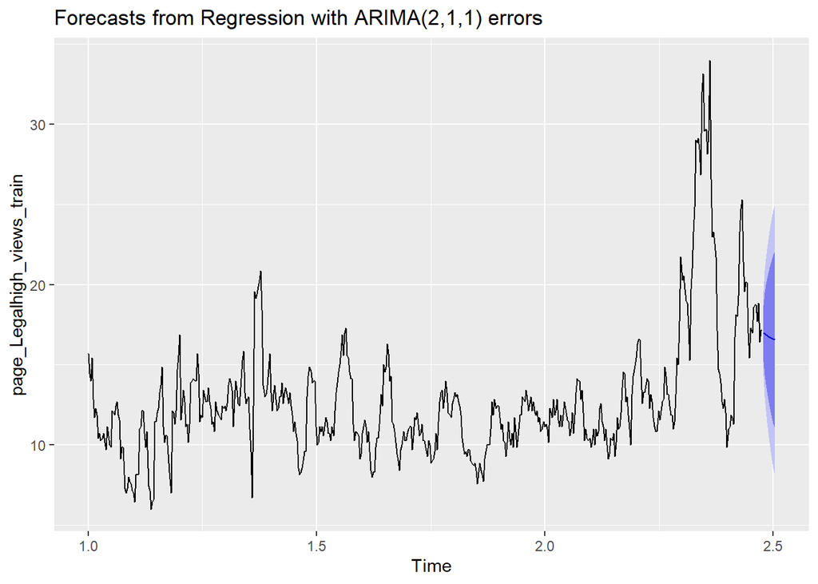

```r
# plotting the forecasts
autoplot(forecast_m1)
```

Now, let’s checkout the residuals for this model

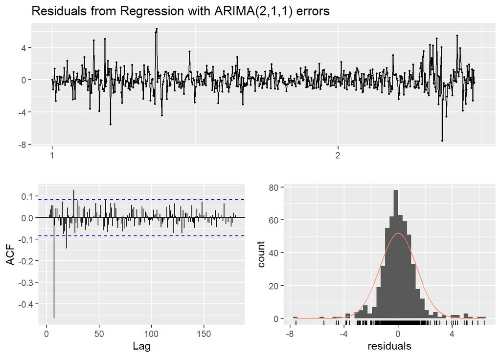

```
##
##  Ljung-Box test
##
## data:  Residuals from Regression with ARIMA(2,1,1) errors
## Q* = 152.28, df = 15, p-value < 2.2e-16
##
## Model df: 10.   Total lags used: 25
```

```r
checkresiduals(m1,lag = 25)
```

```r
#checking mean of the residuals
mean(m1$residuals)
```

```
## [1] -0.0001606569
```

1. From the ACF, we can see that the ACF does not exactly resemble white noise because some of the spikes are significant. This indicates that our model was not able to capture the systematic patterns that we had in our data.
2. Looking at the time-series of the residuals, the mean is almost = 0.
3. Looking at the histogram of the residuals, we see its fairly mormally distributed with few outliers.
4. The p-value obtained from Ljung-Box test for the residuals also confirms that the the residuals are not independently distributed.

## TBATS model

Now, we have seen that how the Regression (Fourier transform) with ARIMA errors has performed. We have also seen that our signal does have multiple seasonal components of 5 days , 4 days and 3 days. So, in order to better capture these patterns, let’s go with something called TBATS model which stands for -

**T**rigonometric terms for seasonality  
**B**ox Cox transformations for heterogeneity  
**A**RMA errors for short term dynamics  
**T**rend (possibly damped)  
**S**easonal (including multiple and non integer periods)

```r
m2 <- tbats(page_Legalhigh_views_train)
m2
```

```
## BATS(0.285, {0,0}, 0.854, -)
##
## Call: tbats(y = page_Legalhigh_views_train)
##
## Parameters
##   Lambda: 0.284999
##   Alpha: 1.154054
##   Beta: -0.1580092
##   Damping Parameter: 0.854247
##
## Seed States:
##            [,1]
## [1,]  3.7675875
## [2,] -0.1497778
## attr(,"lambda")
## [1] 0.2849987
##
## Sigma: 0.2073457
## AIC: 3649.525
```

Just dissecting this model that was chosen -

1. The model has applied Box-Cox transformation of lambda = 0.285
2. The ARMA error is {0,0}
3. A damping parametr of 0.854 has been applied

Forecasting for 10 days with this model -

```r
forecast_m2 <- forecast(m2,h=10)
accuracy(forecast_m2$mean[1:10],page_Legalhigh_views_test)
```

```
##                ME     RMSE      MAE      MPE     MAPE        ACF1
## Test set 1.838646 2.060392 1.838646 9.418934 9.418934 0.005027002
##          Theil's U
## Test set  1.763049
```

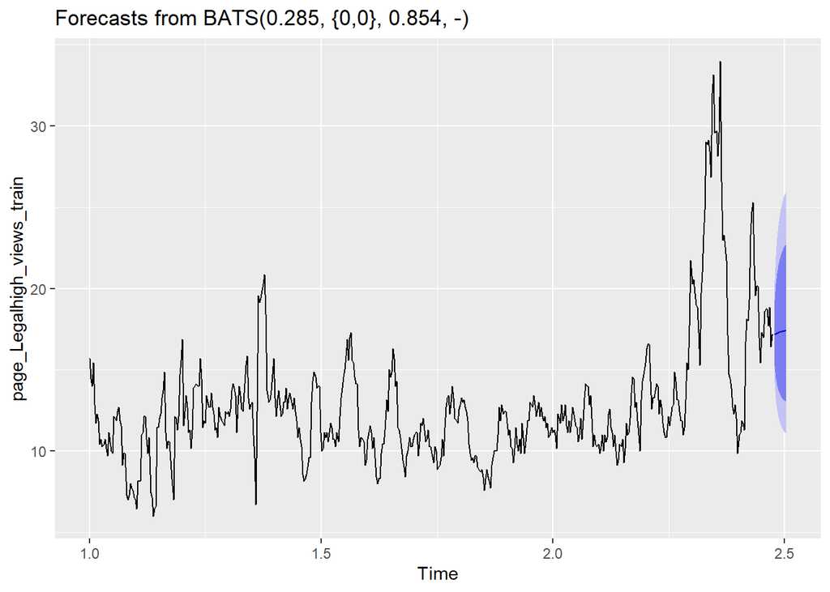

```r
autoplot(forecast_m2)
```

Now, let’s check how the residuals for this model look

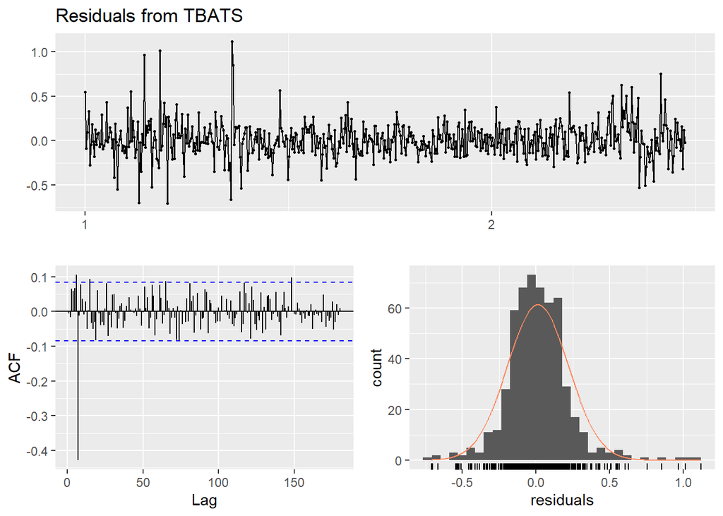

```
##
##  Ljung-Box test
##
## data:  Residuals from TBATS
## Q* = 219.15, df = 102, p-value = 1.491e-10
##
## Model df: 6.   Total lags used: 108
```

```r
checkresiduals(m2)
```

```r
mean(m2$errors)
```

```
## [1] 0.01245048
```

1. From the ACF, we can see that the ACF does not exactly resemble white noise because some of the spikes are significant. This indicates that our model was not able to capture the systematic patterns that we had in our data.
2. Looking at the time-series of the residuals, the mean is almost = 0.
3. Looking at the histogram of the residuals, we see its fairly mormally distributed with few outliers.
4. The p-value obtained from Ljung-Box test for the residuals also confirms that the the residuals are not independently distributed.

We also see that the mean of the residuals is closer to zero for Regression with ARIMA errors than for TBATS model.

But, both the models need some improvement as indicated by the analysis of the residuals.